# Unsupervised Machine Learning with PySpark: Clustering

In this example we turn to **unsupervised machine learning**: Given a dataset without predefined labels, our task is to find structure in the data. A typical approach to this problem is **clustering** - find **clusters** of similar datapoints that group together

## Preamble

```python
%matplotlib inline
```

```python
import findspark
findspark.init()
import pyspark
```

```python
spark = pyspark.sql.SparkSession \
    .builder \
    .appName("Clustering Example") \
    .getOrCreate()
```

## The Iris data set

[figure not shown]

> The Iris flower data set or "Fisher's Iris data set" is a multivariate data set introduced by the British statistician and biologist Ronald Fisher in his 1936 paper *The use of multiple measurements in taxonomic problems* as an example of linear discriminant analysis.

> The data set consists of 50 samples from each of three species of Iris (*Iris setosa*, *Iris virginica* and *Iris versicolor*). Four features were measured from each sample: the length and the width of the sepals and petals, in centimetres. Based on the combination of these four features, Fisher developed a linear discriminant model to distinguish the species from each other. — ["Iris flower data set," Wikipedia](https://en.wikipedia.org/wiki/Iris_flower_data_set)

## Loading the Data

```python
import pandas
import sklearn
```

```python
data = spark.read \
    .format("csv") \
    .option("header", "true") \
    .schema("sepal_length DOUBLE, sepal_width DOUBLE, petal_length DOUBLE, petal_width DOUBLE, species STRING") \
    .load("../.assets/data/iris/iris.csv")
```

```python
data.show()
```

```
+------------+-----------+------------+-----------+-------+
|sepal_length|sepal_width|petal_length|petal_width|species|
+------------+-----------+------------+-----------+-------+
|         5.1|        3.5|         1.4|        0.2|      0|
|         4.9|        3.0|         1.4|        0.2|      0|
|         4.7|        3.2|         1.3|        0.2|      0|
|         4.6|        3.1|         1.5|        0.2|      0|
|         5.0|        3.6|         1.4|        0.2|      0|
|         5.4|        3.9|         1.7|        0.4|      0|
|         4.6|        3.4|         1.4|        0.3|      0|
|         5.0|        3.4|         1.5|        0.2|      0|
|         4.4|        2.9|         1.4|        0.2|      0|
|         4.9|        3.1|         1.5|        0.1|      0|
|         5.4|        3.7|         1.5|        0.2|      0|
|         4.8|        3.4|         1.6|        0.2|      0|
|         4.8|        3.0|         1.4|        0.1|      0|
|         4.3|        3.0|         1.1|        0.1|      0|
|         5.8|        4.0|         1.2|        0.2|      0|
|         5.7|        4.4|         1.5|        0.4|      0|
|         5.4|        3.9|         1.3|        0.4|      0|
|         5.1|        3.5|         1.4|        0.3|      0|
|         5.7|        3.8|         1.7|        0.3|      0|
|         5.1|        3.8|         1.5|        0.3|      0|
+------------+-----------+------------+-----------+-------+
only showing top 20 rows
```

```python
data.schema
```

```
StructType(List(StructField(sepal_length,DoubleType,true),StructField(sepal_width,DoubleType,true),StructField(petal_length,DoubleType,true),StructField(petal_width,DoubleType,true),StructField(species,StringType,true)))
```

## Applying the Clustering Algorithm

In the following we apply the **[k-means clustering algorithm](https://en.m.wikipedia.org/wiki/K-means_clustering)**, a popular choice for getting started with clustering on a new dataset.

```python
from pyspark.ml.clustering import KMeans
```

As the name says, *k-means clustering* has one **parameter**, $k$, which is the number of clusters to be detected in the data. The algorithm will place $k$ cluster centers and assign each datapoint to the closest one. In our example, we know that we are looking for three different species of Iris, and in the hope that they can be found as clusters in the measurements, we set $k = 3$:

```python
# Trains a k-means model.
kmeans = KMeans().setK(3)
```

The rest of the workflow is standard procedure for ML with Spark: Collect the feature columns into a single feature vector column. Fit the estimator - here, our k-means clustering algorithm. Transform the data with the resulting trained model - the result are cluster labels for each data point.

```python
from pyspark.ml.feature import VectorAssembler
from pyspark.ml import Pipeline
```

```python
feature_cols = ["sepal_length", "sepal_width", "petal_length", "petal_width"]
```

```python
assemble_features = VectorAssembler(inputCols=feature_cols,
                                    outputCol="features")
```

```python
data = assemble_features.transform(data)
```

```python
kmeans_model = kmeans.fit(data)
```

```python
labelled = kmeans_model.transform(data)
labelled.show()
```

```
+------------+-----------+------------+-----------+-------+-----------------+----------+
|sepal_length|sepal_width|petal_length|petal_width|species|         features|prediction|
+------------+-----------+------------+-----------+-------+-----------------+----------+
|         5.1|        3.5|         1.4|        0.2|      0|[5.1,3.5,1.4,0.2]|         0|
|         4.9|        3.0|         1.4|        0.2|      0|[4.9,3.0,1.4,0.2]|         0|
|         4.7|        3.2|         1.3|        0.2|      0|[4.7,3.2,1.3,0.2]|         0|
|         4.6|        3.1|         1.5|        0.2|      0|[4.6,3.1,1.5,0.2]|         0|
|         5.0|        3.6|         1.4|        0.2|      0|[5.0,3.6,1.4,0.2]|         0|
|         5.4|        3.9|         1.7|        0.4|      0|[5.4,3.9,1.7,0.4]|         0|
|         4.6|        3.4|         1.4|        0.3|      0|[4.6,3.4,1.4,0.3]|         0|
|         5.0|        3.4|         1.5|        0.2|      0|[5.0,3.4,1.5,0.2]|         0|
|         4.4|        2.9|         1.4|        0.2|      0|[4.4,2.9,1.4,0.2]|         0|
|         4.9|        3.1|         1.5|        0.1|      0|[4.9,3.1,1.5,0.1]|         0|
|         5.4|        3.7|         1.5|        0.2|      0|[5.4,3.7,1.5,0.2]|         0|
|         4.8|        3.4|         1.6|        0.2|      0|[4.8,3.4,1.6,0.2]|         0|
|         4.8|        3.0|         1.4|        0.1|      0|[4.8,3.0,1.4,0.1]|         0|
|         4.3|        3.0|         1.1|        0.1|      0|[4.3,3.0,1.1,0.1]|         0|
|         5.8|        4.0|         1.2|        0.2|      0|[5.8,4.0,1.2,0.2]|         0|
|         5.7|        4.4|         1.5|        0.4|      0|[5.7,4.4,1.5,0.4]|         0|
|         5.4|        3.9|         1.3|        0.4|      0|[5.4,3.9,1.3,0.4]|         0|
|         5.1|        3.5|         1.4|        0.3|      0|[5.1,3.5,1.4,0.3]|         0|
|         5.7|        3.8|         1.7|        0.3|      0|[5.7,3.8,1.7,0.3]|         0|
|         5.1|        3.8|         1.5|        0.3|      0|[5.1,3.8,1.5,0.3]|         0|
+------------+-----------+------------+-----------+-------+-----------------+----------+
only showing top 20 rows
```

## Interpretation

Computing a clustering is the easy part. The bigger data analysis task is still ahead of us: How to evaluate and interpret the result? What does a cluster represent? How well does it match the partition of the data we were trying to find? There are many strategies we can apply, and we only briefly look at some of them.

### Cluster Centers

Like any **centroid clustering** algorithm, the k-Means algorithm defines a cluster as the set of data points close to a central data point, and iteratively tries to find good centers so that the overall distance is minimized. This enables one way of interpreting the result: After the algorithm terminates, the cluster centers can be treated as "typical" and "representative" for their respective cluster.

```python
centers = kmeans_model.clusterCenters()
print("Cluster Centers: ")
for center in centers:
    print(list(zip(feature_cols, center)))
```

```
Cluster Centers:
[('sepal_length', 5.005999999999999), ('sepal_width', 3.4180000000000006), ('petal_length', 1.4640000000000002), ('petal_width', 0.2439999999999999)]
[('sepal_length', 5.88360655737705), ('sepal_width', 2.7409836065573776), ('petal_length', 4.388524590163936), ('petal_width', 1.4344262295081969)]
[('sepal_length', 6.853846153846153), ('sepal_width', 3.0769230769230766), ('petal_length', 5.715384615384615), ('petal_width', 2.053846153846153)]
```

In this case, we can say that a specimen of the Iris plant from cluster 1 typically has a sepal length of around 5.8 cm, and so on. Let us compare that with the **ground truth** given by the species label:

```python
from pyspark.sql.functions import avg, col
for i in range(3):
    print("species ", i)
    data[data["species"] == i].agg(dict((feature, "avg") for feature in feature_cols)).show()
```

```
species  0
+------------------+------------------+-----------------+-----------------+
|  avg(sepal_width)|  avg(petal_width)|avg(sepal_length)|avg(petal_length)|
+------------------+------------------+-----------------+-----------------+
|3.4180000000000006|0.2439999999999999|5.005999999999999|            1.464|
+------------------+------------------+-----------------+-----------------+

species  1
+------------------+------------------+-----------------+-----------------+
|  avg(sepal_width)|  avg(petal_width)|avg(sepal_length)|avg(petal_length)|
+------------------+------------------+-----------------+-----------------+
|2.7700000000000005|1.3259999999999998|            5.936|             4.26|
+------------------+------------------+-----------------+-----------------+

species  2
+------------------+----------------+-----------------+-----------------+
|  avg(sepal_width)|avg(petal_width)|avg(sepal_length)|avg(petal_length)|
+------------------+----------------+-----------------+-----------------+
|2.9739999999999998|           2.026|6.587999999999998|            5.552|
+------------------+----------------+-----------------+-----------------+
```

### Visualization

In order to inspect the clusters found, we can use data visualization techniques such as **scatter plots**. The Python ecosystem provides powerful plotting tools such as [`matplotlib`](https://matplotlib.org/) and [`seaborn`](https://seaborn.pydata.org/index.html). For most visualization purposes it makes sense to pull a small data sample computed with Spark, then leave the Spark territory and convert to a `pandas.DataFrame` to work with those tools.

```python
import seaborn
```

```python
labelled_pd = labelled.toPandas()
```

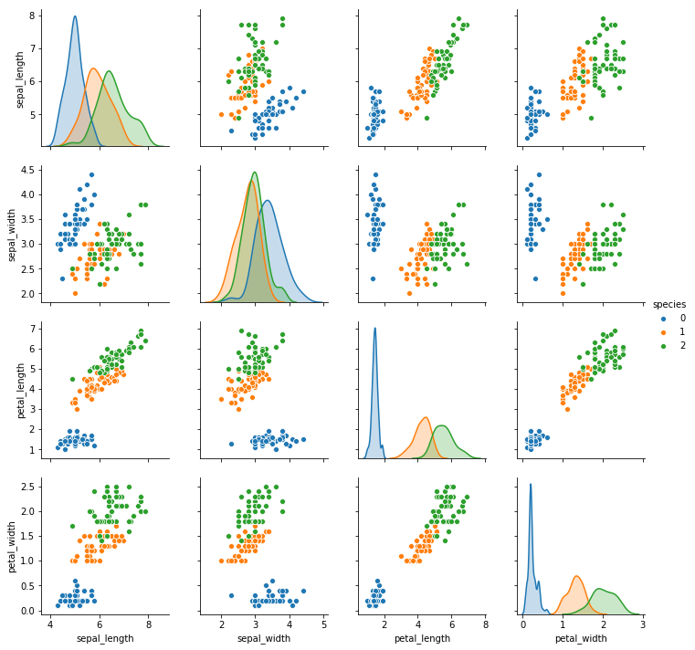

```python
seaborn.pairplot(labelled_pd, vars=["sepal_length", "sepal_width", "petal_length", "petal_width"], hue="species")
```

*This notebook is licensed under a [Creative Commons Attribution 4.0 International License (CC BY 4.0)](https://creativecommons.org/licenses/by/4.0/). Copyright © 2018 [Point 8 GmbH](https://point-8.de)*